# Bellabeat Capstone

### **Cleaning & Formatting**

#### Look for duplicates in the datasets

```r
library(dplyr)
library(tidyverse)

sum(duplicated(daily_activity))
```

```
## [1] 0
```

```r
sum(duplicated(sleep))
```

```
## [1] 3
```

```r
sum(duplicated(hourly_calories))
```

```
## [1] 0
```

```r
sum(duplicated(hourly_steps))
```

```
## [1] 0
```

```r
sum(duplicated(hourly_intensities))
```

```
## [1] 0
```

```r
daily_activity %>% distinct(Id) %>%  drop_na()
```

```
## # A tibble: 33 × 1
##            Id
##         <dbl>
##  1 1503960366
##  2 1624580081
##  3 1644430081
##  4 1844505072
##  5 1927972279
##  6 2022484408
##  7 2026352035
##  8 2320127002
##  9 2347167796
## 10 2873212765
## # ℹ 23 more rows
```

```r
sleep %>% distinct(Id) %>%  drop_na()
```

```
## # A tibble: 24 × 1
##            Id
##         <dbl>
##  1 1503960366
##  2 1644430081
##  3 1844505072
##  4 1927972279
##  5 2026352035
##  6 2320127002
##  7 2347167796
##  8 3977333714
##  9 4020332650
## 10 4319703577
## # ℹ 14 more rows
```

```r
hourly_calories %>% distinct (Id) %>% drop_na()
```

```
## # A tibble: 33 × 1
##            Id
##         <dbl>
##  1 1503960366
##  2 1624580081
##  3 1644430081
##  4 1844505072
##  5 1927972279
##  6 2022484408
##  7 2026352035
##  8 2320127002
##  9 2347167796
## 10 2873212765
## # ℹ 23 more rows
```

```r
hourly_steps %>% distinct (Id) %>% drop_na()
```

```
## # A tibble: 33 × 1
##            Id
##         <dbl>
##  1 1503960366
##  2 1624580081
##  3 1644430081
##  4 1844505072
##  5 1927972279
##  6 2022484408
##  7 2026352035
##  8 2320127002
##  9 2347167796
## 10 2873212765
## # ℹ 23 more rows
```

```r
hourly_intensities %>% distinct (Id) %>% drop_na()
```

```
## # A tibble: 33 × 1
##            Id
##         <dbl>
##  1 1503960366
##  2 1624580081
##  3 1644430081
##  4 1844505072
##  5 1927972279
##  6 2022484408
##  7 2026352035
##  8 2320127002
##  9 2347167796
## 10 2873212765
## # ℹ 23 more rows
```

```r
daily_sleep <- sleep %>% distinct(Id, .keep_all = TRUE)
```

#### Verify that duplicates have been removed from the sleep data

```r
sum(duplicated(daily_sleep))
```

```
## [1] 0
```

#### Clean names

```r
library(janitor)

clean_names(daily_activity)
```

```
## # A tibble: 940 × 15
##            id activity_date total_steps total_distance tracker_distance
##         <dbl> <chr>               <dbl>          <dbl>            <dbl>
##  1 1503960366 4/12/2016           13162           8.5              8.5
##  2 1503960366 4/13/2016           10735           6.97             6.97
##  3 1503960366 4/14/2016           10460           6.74             6.74
##  4 1503960366 4/15/2016            9762           6.28             6.28
##  5 1503960366 4/16/2016           12669           8.16             8.16
##  6 1503960366 4/17/2016            9705           6.48             6.48
##  7 1503960366 4/18/2016           13019           8.59             8.59
##  8 1503960366 4/19/2016           15506           9.88             9.88
##  9 1503960366 4/20/2016           10544           6.68             6.68
## 10 1503960366 4/21/2016            9819           6.34             6.34
## # ℹ 930 more rows
## # ℹ 10 more variables: logged_activities_distance <dbl>,
## #   very_active_distance <dbl>, moderately_active_distance <dbl>,
## #   light_active_distance <dbl>, sedentary_active_distance <dbl>,
## #   very_active_minutes <dbl>, fairly_active_minutes <dbl>,
## #   lightly_active_minutes <dbl>, sedentary_minutes <dbl>, calories <dbl>
```

```r
clean_names(daily_sleep)
```

```
## # A tibble: 24 × 5
##          id sleep_day total_sleep_records total_minutes_asleep total_time_in_bed
##       <dbl> <chr>                   <dbl>                <dbl>             <dbl>
##  1   1.50e9 4/12/201…                   1                  327               346
##  2   1.64e9 4/29/201…                   1                  119               127
##  3   1.84e9 4/15/201…                   1                  644               961
##  4   1.93e9 4/12/201…                   3                  750               775
##  5   2.03e9 4/12/201…                   1                  503               546
##  6   2.32e9 4/23/201…                   1                   61                69
##  7   2.35e9 4/13/201…                   1                  467               531
##  8   3.98e9 4/12/201…                   1                  274               469
##  9   4.02e9 4/12/201…                   1                  501               541
## 10   4.32e9 4/14/201…                   1                  535               557
## # ℹ 14 more rows
```

```r
clean_names(hourly_calories)
```

```
## # A tibble: 22,099 × 3
##            id activity_hour         calories
##         <dbl> <chr>                    <dbl>
##  1 1503960366 4/12/2016 12:00:00 AM       81
##  2 1503960366 4/12/2016 1:00:00 AM        61
##  3 1503960366 4/12/2016 2:00:00 AM        59
##  4 1503960366 4/12/2016 3:00:00 AM        47
##  5 1503960366 4/12/2016 4:00:00 AM        48
##  6 1503960366 4/12/2016 5:00:00 AM        48
##  7 1503960366 4/12/2016 6:00:00 AM        48
##  8 1503960366 4/12/2016 7:00:00 AM        47
##  9 1503960366 4/12/2016 8:00:00 AM        68
## 10 1503960366 4/12/2016 9:00:00 AM       141
## # ℹ 22,089 more rows
```

```r
clean_names(hourly_steps)
```

```
## # A tibble: 22,099 × 3
##            id activity_hour         step_total
##         <dbl> <chr>                      <dbl>
##  1 1503960366 4/12/2016 12:00:00 AM        373
##  2 1503960366 4/12/2016 1:00:00 AM         160
##  3 1503960366 4/12/2016 2:00:00 AM         151
##  4 1503960366 4/12/2016 3:00:00 AM           0
##  5 1503960366 4/12/2016 4:00:00 AM           0
##  6 1503960366 4/12/2016 5:00:00 AM           0
##  7 1503960366 4/12/2016 6:00:00 AM           0
##  8 1503960366 4/12/2016 7:00:00 AM           0
##  9 1503960366 4/12/2016 8:00:00 AM         250
## 10 1503960366 4/12/2016 9:00:00 AM        1864
## # ℹ 22,089 more rows
```

```r
clean_names(hourly_intensities)
```

```
## # A tibble: 22,099 × 4
##            id activity_hour         total_intensity average_intensity
##         <dbl> <chr>                           <dbl>             <dbl>
##  1 1503960366 4/12/2016 12:00:00 AM              20             0.333
##  2 1503960366 4/12/2016 1:00:00 AM                8             0.133
##  3 1503960366 4/12/2016 2:00:00 AM                7             0.117
##  4 1503960366 4/12/2016 3:00:00 AM                0             0
##  5 1503960366 4/12/2016 4:00:00 AM                0             0
##  6 1503960366 4/12/2016 5:00:00 AM                0             0
##  7 1503960366 4/12/2016 6:00:00 AM                0             0
##  8 1503960366 4/12/2016 7:00:00 AM                0             0
##  9 1503960366 4/12/2016 8:00:00 AM               13             0.217
## 10 1503960366 4/12/2016 9:00:00 AM               30             0.5
## # ℹ 22,089 more rows
```

#### Fix date & time formats

```r
daily_activity$ActivityDate=as.POSIXct(daily_activity$ActivityDate, format="%m/%d/%Y", tz=Sys.timezone())
daily_activity$date <- format(daily_activity$ActivityDate, format = "%m/%d/%y")

daily_sleep$SleepDay=as.POSIXct(daily_sleep$SleepDay, format="%m/%d/%Y", tz=Sys.timezone())
daily_sleep$date <- format(daily_sleep$SleepDay, format = "%m/%d/%y")

hourly_calories$ActivityHour=as.POSIXct(hourly_calories$ActivityHour, format="%m/%d/%Y", tz=Sys.timezone())
hourly_calories$date <- format(hourly_calories$ActivityHour, format = "%m/%d/%y")

hourly_steps$ActivityHour=as.POSIXct(hourly_steps$ActivityHour, format="%m/%d/%Y %I:%M:%S %p", tz=Sys.timezone())
hourly_steps$time <- format(hourly_steps$ActivityHour, format = "%H:%M:%S")
hourly_steps$date <- format(hourly_steps$ActivityHour, format= "%m/%d/%y")

hourly_intensities$ActivityHour=as.POSIXct(hourly_intensities$ActivityHour, format="%m/%d/%Y %I:%M:%S %p", tz=Sys.timezone())
hourly_intensities$time <- format(hourly_intensities$ActivityHour, format = "%H:%M:%S")
hourly_intensities$date <- format(hourly_intensities$ActivityHour, format= "%m/%d/%y")
```

#### Verify the number of users for our datasets

```r
n_distinct(daily_activity$Id)
```

```
## [1] 33
```

```r
n_distinct(daily_sleep$Id)
```

```
## [1] 24
```

```r
n_distinct(hourly_calories$Id)
```

```
## [1] 33
```

```r
n_distinct(hourly_steps$Id)
```

```
## [1] 33
```

```r
n_distinct(hourly_intensities$Id)
```

```
## [1] 33
```

We have verified that all our data sets have 33 users, except the sleep data set that has 24 users.

## **Analyze & Visualize**

We will begin our analysis by getting a summary of statistics from the different data sets.

#### Daily Activity Statistics

```r
daily_activity %>%
  select(TotalSteps, TotalDistance, SedentaryMinutes, Calories) %>%
  summary()
```

```
##    TotalSteps    TotalDistance    SedentaryMinutes    Calories
##  Min.   :    0   Min.   : 0.000   Min.   :   0.0   Min.   :   0
##  1st Qu.: 3790   1st Qu.: 2.620   1st Qu.: 729.8   1st Qu.:1828
##  Median : 7406   Median : 5.245   Median :1057.5   Median :2134
##  Mean   : 7638   Mean   : 5.490   Mean   : 991.2   Mean   :2304
##  3rd Qu.:10727   3rd Qu.: 7.713   3rd Qu.:1229.5   3rd Qu.:2793
##  Max.   :36019   Max.   :28.030   Max.   :1440.0   Max.   :4900
```

From this data set, we can see that: * Mean Steps: 7638 * Mean Distance: 5.4 km * Mean Sedentary Minutes: 991.2 min * Mean Calories burned: 2304

#### Activity Minutes per Category Statistics

```r
daily_activity %>%
  select(VeryActiveMinutes, FairlyActiveMinutes, LightlyActiveMinutes) %>%
  summary ()
```

```
##  VeryActiveMinutes FairlyActiveMinutes LightlyActiveMinutes
##  Min.   :  0.00    Min.   :  0.00      Min.   :  0.0
##  1st Qu.:  0.00    1st Qu.:  0.00      1st Qu.:127.0
##  Median :  4.00    Median :  6.00      Median :199.0
##  Mean   : 21.16    Mean   : 13.56      Mean   :192.8
##  3rd Qu.: 32.00    3rd Qu.: 19.00      3rd Qu.:264.0
##  Max.   :210.00    Max.   :143.00      Max.   :518.0
```

#### Calorie Summary Statistics

```r
daily_activity %>%
  select(Calories) %>%
  summary()
```

```
##     Calories
##  Min.   :   0
##  1st Qu.:1828
##  Median :2134
##  Mean   :2304
##  3rd Qu.:2793
##  Max.   :4900
```

#### Sleep Summary Statistics

```r
daily_sleep %>%
  select(TotalSleepRecords, TotalMinutesAsleep, TotalTimeInBed) %>%
  summary()
```

```
##  TotalSleepRecords TotalMinutesAsleep TotalTimeInBed
##  Min.   :1.000     Min.   : 61.0      Min.   : 69.0
##  1st Qu.:1.000     1st Qu.:313.8      1st Qu.:353.5
##  Median :1.000     Median :427.0      Median :460.5
##  Mean   :1.125     Mean   :390.7      Mean   :432.4
##  3rd Qu.:1.000     3rd Qu.:499.5      3rd Qu.:527.2
##  Max.   :3.000     Max.   :750.0      Max.   :961.0
```

#### Merge Data

It would be useful for our analysis to merge the daily activity data with the daily sleep data to look for trends between sleep and activity. The ‘Id’ and ‘date’ columns can be used to join the data.

```r
merged_data <- merge(daily_sleep, daily_activity, by=c('Id', 'date'))

head(merged_data)
```

```
##           Id     date   SleepDay TotalSleepRecords TotalMinutesAsleep
## 1 1503960366 04/12/16 2016-04-12                 1                327
## 2 1644430081 04/29/16 2016-04-29                 1                119
## 3 1844505072 04/15/16 2016-04-15                 1                644
## 4 1927972279 04/12/16 2016-04-12                 3                750
## 5 2026352035 04/12/16 2016-04-12                 1                503
## 6 2320127002 04/23/16 2016-04-23                 1                 61
##   TotalTimeInBed ActivityDate TotalSteps TotalDistance TrackerDistance
## 1            346   2016-04-12      13162          8.50            8.50
## 2            127   2016-04-29       3176          2.31            2.31
## 3            961   2016-04-15       3844          2.54            2.54
## 4            775   2016-04-12        678          0.47            0.47
## 5            546   2016-04-12       4414          2.74            2.74
## 6             69   2016-04-23       5079          3.42            3.42
##   LoggedActivitiesDistance VeryActiveDistance ModeratelyActiveDistance
```

[output cut: 20 more lines]

### **Visualization of Data**

```r
library(ggplot2)
```

#### Steps vs Calories

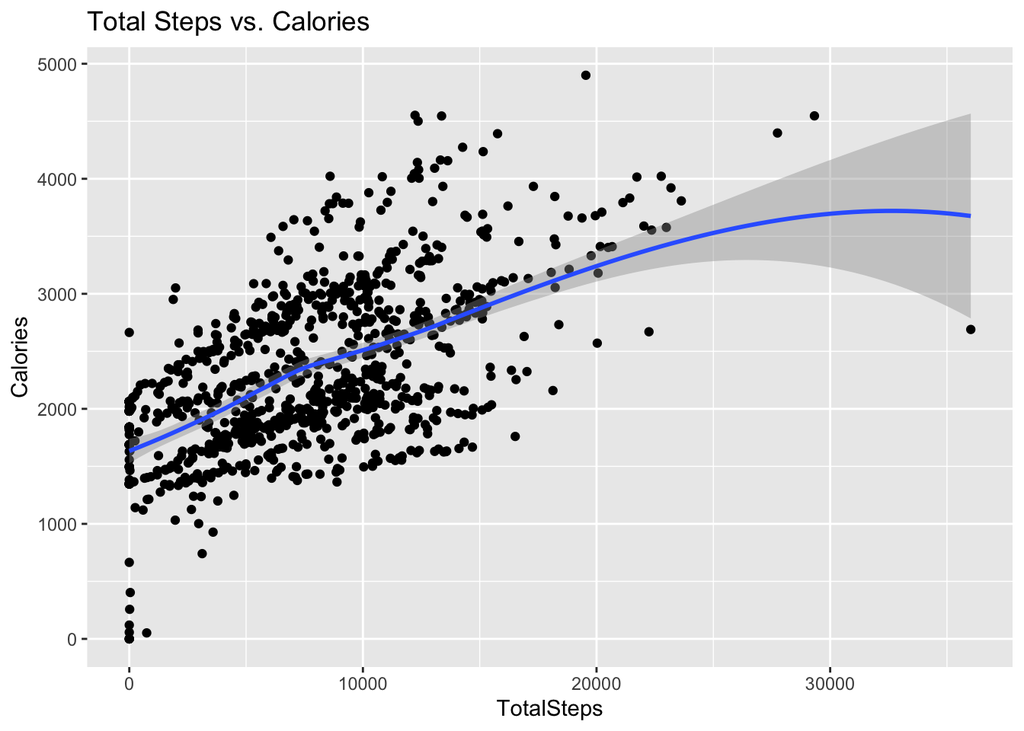

```r
ggplot(data=daily_activity, mapping=aes(x=TotalSteps, y=Calories)) +
  geom_point() + geom_smooth() + labs(title= "Total Steps vs. Calories")
```

Trend: Calories increase as steps increase

#### Total Minutes Asleep vs Total Time in Bed

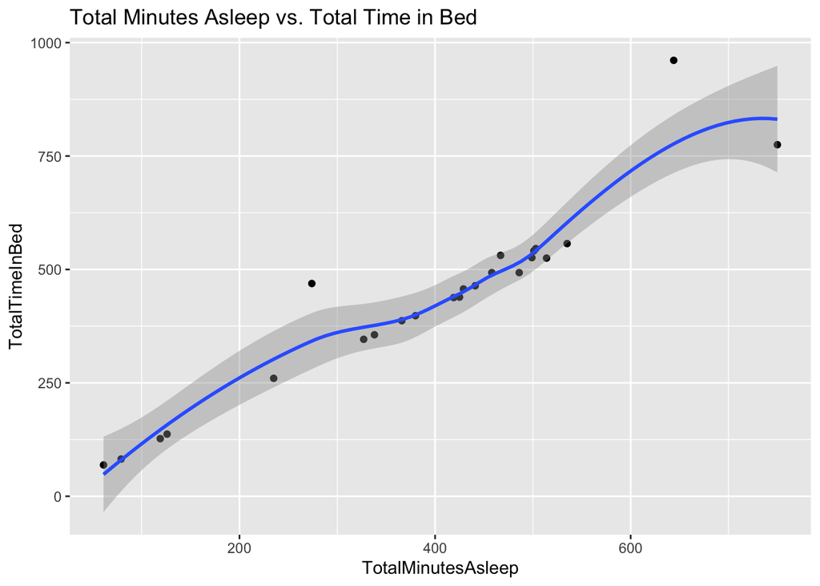

```r
ggplot(data=daily_sleep, mapping=aes(x=TotalMinutesAsleep, y=TotalTimeInBed))+
  geom_point()+ geom_smooth() + labs(title="Total Minutes Asleep vs. Total Time in Bed")
```

Trend: Total minutes asleep increase as total time in bed increase

#### Intensity vs Time

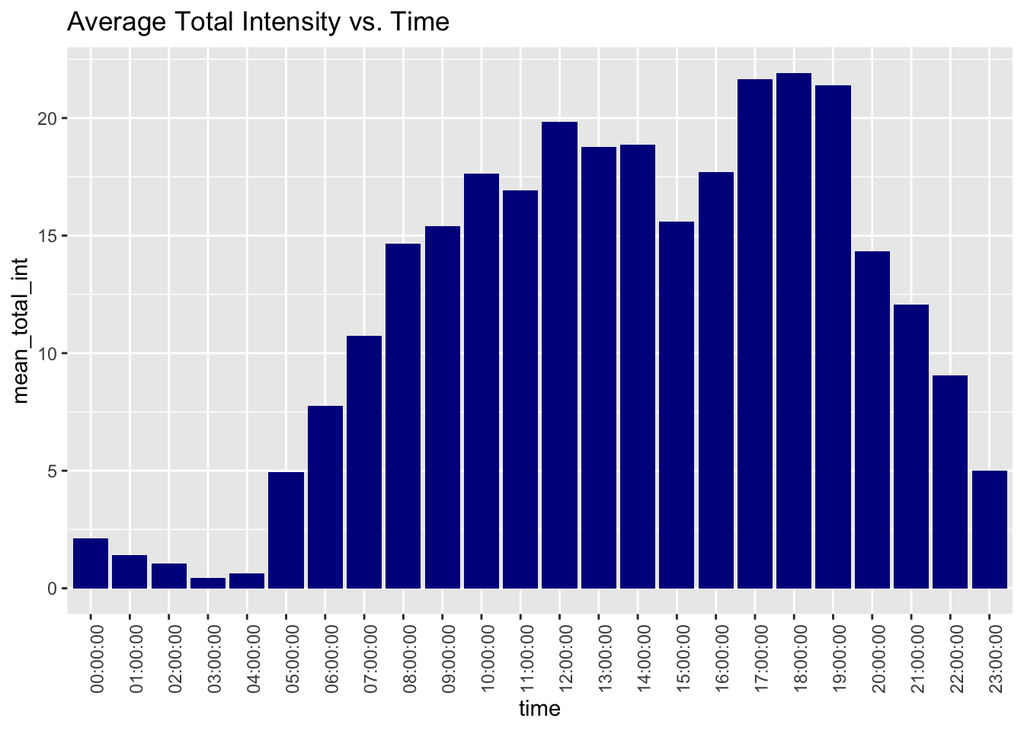

```r
int_new <- hourly_intensities %>%
  group_by(time) %>%
  drop_na() %>%
  summarise(mean_total_int=mean(TotalIntensity))

ggplot(data=int_new, aes(x=time, y=mean_total_int)) +
  geom_histogram(stat = "identity", fill='darkblue')+
  theme(axis.text.x = element_text(angle = 90))+
  labs(title="Average Total Intensity vs. Time")
```

Trend: People are at their highest activity intensities between 8am-8pm

#### Steps vs Time

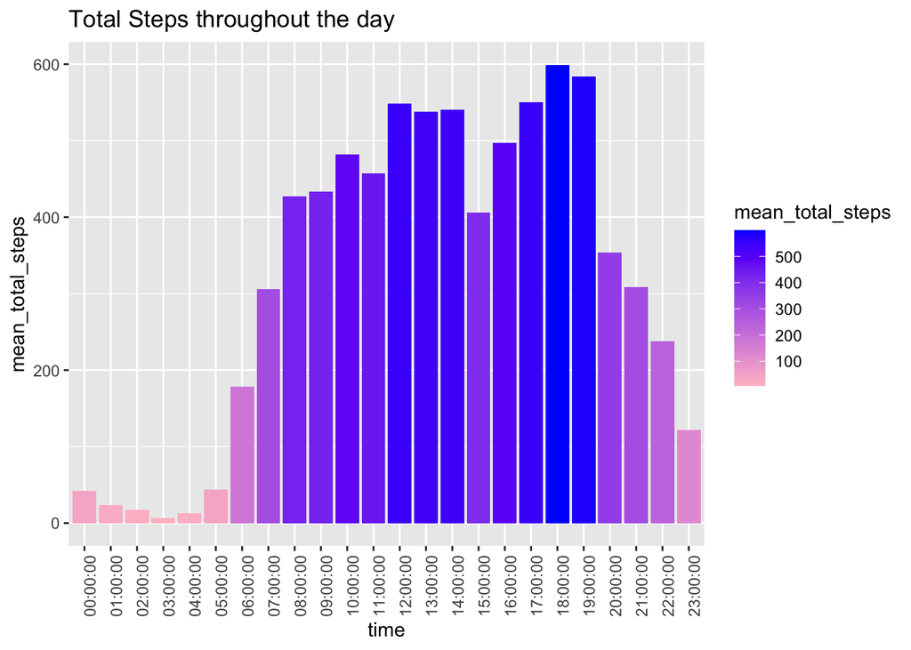

```r
View(hourly_steps)

steps_new <- hourly_steps %>%
  group_by(time) %>%
  drop_na() %>%
  summarise(mean_total_steps=mean(StepTotal))

ggplot(data=steps_new)+ geom_col(mapping=aes(x=time, y=mean_total_steps, fill=mean_total_steps))+
  scale_fill_gradient(low='pink', high='blue')+
  theme(axis.text.x = element_text(angle = 90))+
  labs(title="Total Steps throughout the day")
```

Trend: Most steps are taken from 8am-8pm

#### Total Minutes Asleep vs Sedentary Minutes

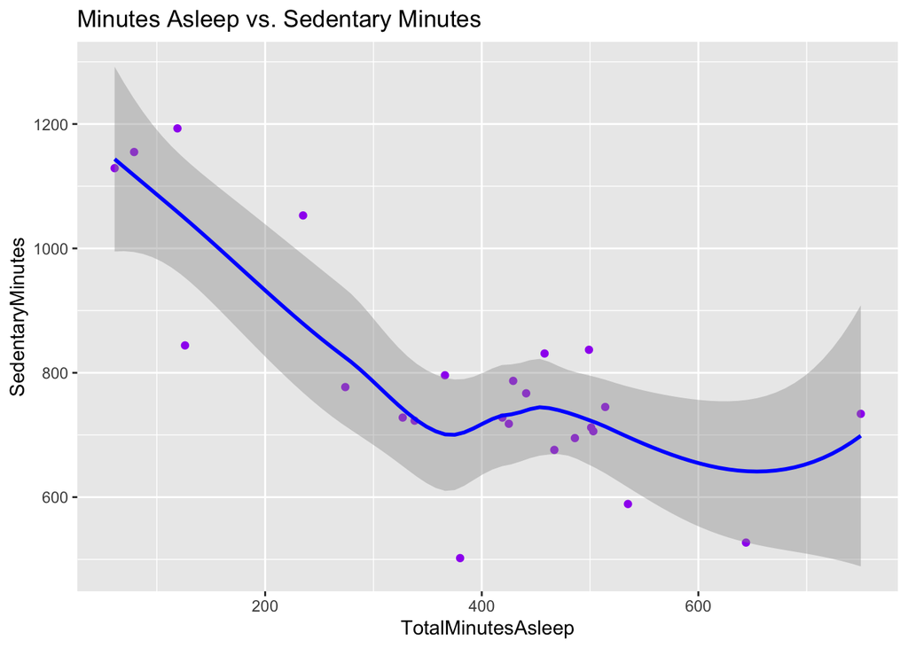

```r
ggplot(data=merged_data, aes(x=TotalMinutesAsleep, y=SedentaryMinutes))+
  geom_point(color='purple')+ geom_smooth(color='blue')+
  labs(title="Minutes Asleep vs. Sedentary Minutes")
```

Trend: As total minutes asleep increases, total sedentary minutes decreases. Therefore, as you sleep better, you are more active or if you are more active, you sleep better.

#### Smart Device Usage

We can look at how often users wore their trackers by categorizing them into “low use”, “moderate use”, and “high use”:

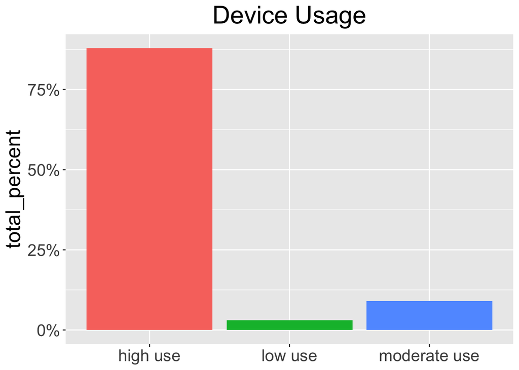

```r
daily_use <- daily_activity %>%
  group_by(Id) %>%
  drop_na() %>%
  summarise(days_used=sum(n())) %>%
  mutate(usage = case_when(
    days_used >= 1 & days_used <= 10 ~ "low use",
    days_used >= 11 & days_used <= 20 ~ "moderate use",
    days_used >= 21 & days_used <= 31 ~ "high use",
  ))

View(daily_use)

daily_use %>%
  group_by(usage) %>%
  summarise(total=n()) %>%
  mutate(totals=sum(total)) %>%
  group_by(usage) %>%
  summarise(total_percent=total/totals) %>%
  ggplot(daily_use, mapping=aes(usage, y=total_percent, fill=usage))+
  geom_col()+scale_y_continuous(labels=scales::percent)+
  theme(legend.position="none")+
  labs(title="Device Usage", x=NULL)+
  theme(legend.position="none", text= element_text(size=20), plot.title=element_text(hjust=0.5))
```

Trend: Majority of tracker usage is categorized as “high use”. So many of the users wore the tracker for 21-31 days.

#### Understanding Users based on Activity Levels

```r
data_by_usertype <- daily_activity %>%
  reframe(
    user_type = factor(case_when(
      SedentaryMinutes > mean(SedentaryMinutes) & LightlyActiveMinutes < mean(LightlyActiveMinutes) & FairlyActiveMinutes < mean(FairlyActiveMinutes) & VeryActiveMinutes < mean(VeryActiveMinutes) ~ "Sedentary",
      SedentaryMinutes < mean(SedentaryMinutes) & LightlyActiveMinutes > mean(LightlyActiveMinutes) & FairlyActiveMinutes < mean(FairlyActiveMinutes) & VeryActiveMinutes < mean(VeryActiveMinutes) ~ "Lightly Active",
      SedentaryMinutes < mean(SedentaryMinutes) & LightlyActiveMinutes < mean(LightlyActiveMinutes) & FairlyActiveMinutes > mean(FairlyActiveMinutes) & VeryActiveMinutes < mean(VeryActiveMinutes) ~ "Fairly Active",
      SedentaryMinutes < mean(SedentaryMinutes) & LightlyActiveMinutes < mean(LightlyActiveMinutes) & FairlyActiveMinutes < mean(FairlyActiveMinutes) & VeryActiveMinutes > mean(VeryActiveMinutes) ~ "Very Active",
    ),levels=c("Sedentary", "Lightly Active", "Fairly Active", "Very Active")), Calories, .group=Id) %>%
  drop_na()
```

We have now created a new table based on User Type.

```r
View(data_by_usertype)
```

Let us take a look at the distribution of user types:

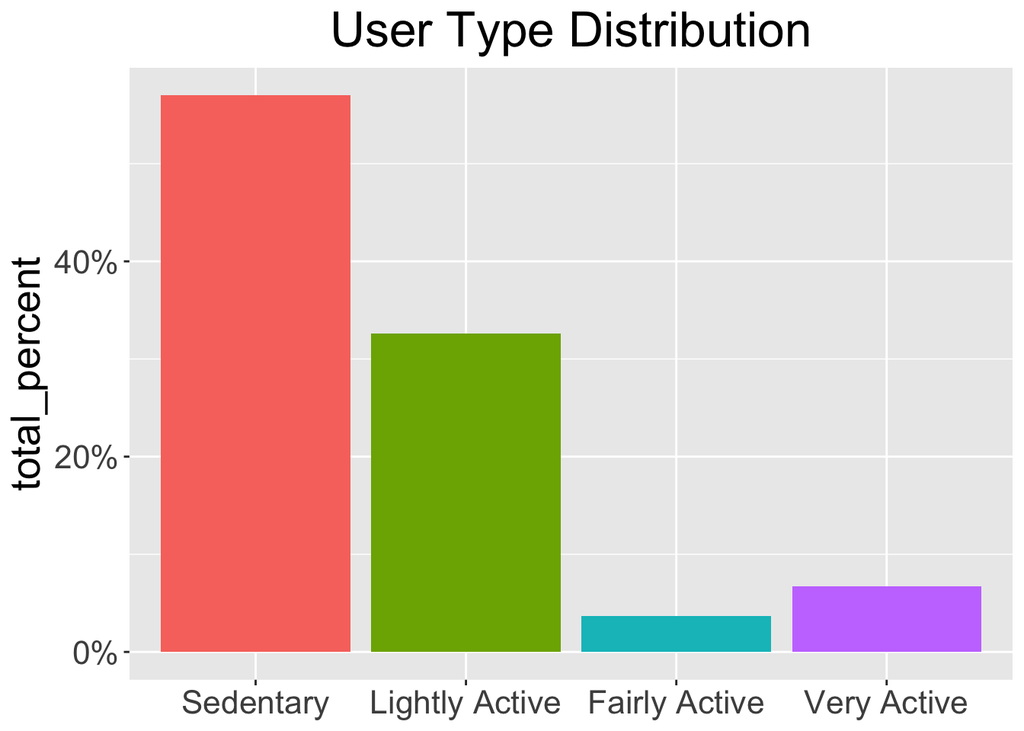

```r
data_by_usertype %>%
  group_by(user_type) %>%
  summarise(total= n()) %>%
  mutate(totals = sum(total)) %>%
  group_by(user_type) %>%
  summarise(total_percent = total/totals) %>%
  ggplot(data_by_usertype, mapping=aes(user_type, y=total_percent, fill=user_type))+
  geom_col() + scale_y_continuous(labels = scales::percent) +
  theme(legend.position ="none")+
  labs(title="User Type Distribution", x=NULL)+
  theme(legend.position="none", text = element_text(size = 20), plot.title = element_text(hjust=0.5))
```

Trend: Most users fall into the Sedentary and Lightly Active Categories

#### Calories Burned by User Type

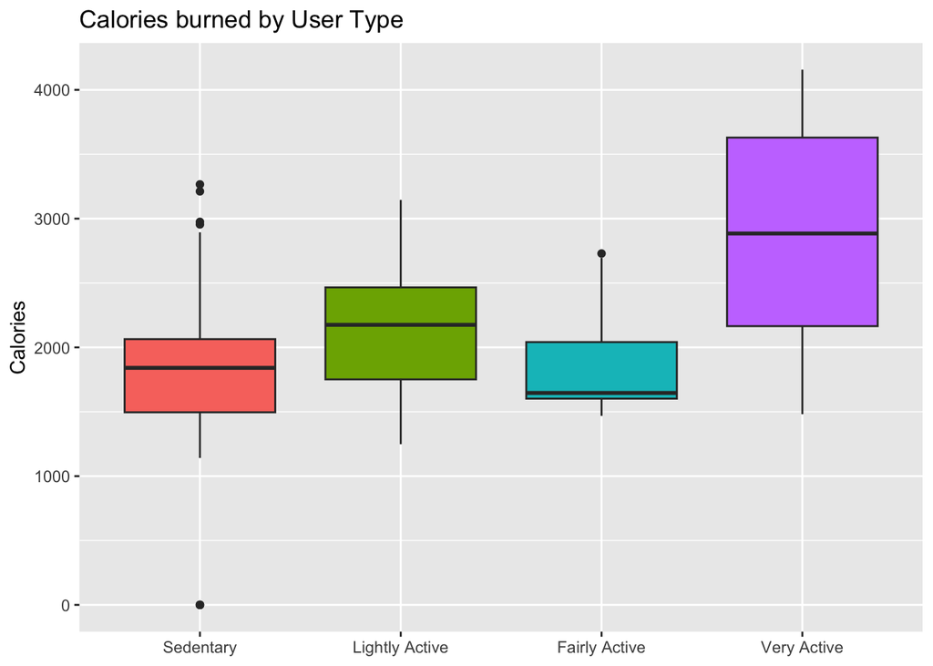

```r
ggplot(data_by_usertype, mapping=aes(user_type, Calories, fill=user_type))+
  geom_boxplot()+
  theme(legend.position="none")+
  labs(title="Calories burned by User Type", x=NULL)
```

Trend: Most calories burned by the very active users

#### Using Total Steps to Categorize Users

First we will need to find out the daily averages of the users:

```r
daily_avg <- merged_data %>%
  group_by(Id) %>%
  summarise(mean_daily_steps = mean(TotalSteps), mean_daily_calories= mean(Calories), mean_daily_sleep= mean(TotalMinutesAsleep))

head(daily_avg)
```

```
## # A tibble: 6 × 4
##           Id mean_daily_steps mean_daily_calories mean_daily_sleep
##        <dbl>            <dbl>               <dbl>            <dbl>
## 1 1503960366            13162                1985              327
## 2 1644430081             3176                2498              119
## 3 1844505072             3844                1725              644
## 4 1927972279              678                2220              750
## 5 2026352035             4414                1459              503
## 6 2320127002             5079                1804               61
```

Now we will classify the users by their average daily steps:

```r
usertype_bysteps <- daily_avg %>%
  mutate(usertype_bysteps = case_when(mean_daily_steps < 5000 ~ "sedentary", mean_daily_steps >= 5000 & mean_daily_steps < 7499 ~ "lightly active", mean_daily_steps >= 7500 & mean_daily_steps <9999 ~ "fairly active", mean_daily_steps >= 10000 ~ "very active"))

head(usertype_bysteps)
```

```
## # A tibble: 6 × 5
##        Id mean_daily_steps mean_daily_calories mean_daily_sleep usertype_bysteps
##     <dbl>            <dbl>               <dbl>            <dbl> <chr>
## 1  1.50e9            13162                1985              327 very active
## 2  1.64e9             3176                2498              119 sedentary
## 3  1.84e9             3844                1725              644 sedentary
## 4  1.93e9              678                2220              750 sedentary
## 5  2.03e9             4414                1459              503 sedentary
## 6  2.32e9             5079                1804               61 lightly active
```

```r
View(usertype_bysteps)
```

Time to figure out the percent of user type based on steps:

```r
usertype_step_percent <- usertype_bysteps %>%
  group_by(usertype_bysteps) %>%
  summarise(total=n()) %>%
  mutate(totals = sum(total)) %>%
  group_by(usertype_bysteps) %>%
  summarise(total_percent= total/totals) %>%
  mutate(labels= scales::percent(total_percent))

usertype_step_percent$usertype_bysteps <- factor(usertype_step_percent$usertype_bysteps, levels = c("very active", "fairly active", "lightly active", "sedentary"))

head(usertype_step_percent)
```

```
## # A tibble: 4 × 3
##   usertype_bysteps total_percent labels
##   <fct>                    <dbl> <chr>
## 1 fairly active           0.208  20.8%
## 2 lightly active          0.0833 8.3%
## 3 sedentary               0.333  33.3%
## 4 very active             0.375  37.5%
```